# Muhammad Zikriya – index

## Police Operational Efficiency Using Output-Oriented BCC DEA with Exogenous Crime Workload

Muhammad Zikriya

Postgraduate Program in Statistics · Universidade Federal de Pernambuco (UFPE)  
GEDAI Research Group

## The operational question

**How efficiently do police units convert existing staff and vehicles into criminal clear-ups, given their observed crime workload?**

- Crime burden is **external workload**, not a discretionary police output.
- Clear-ups are the **desirable operational output**.
- DEA identifies a **relative best-practice frontier**, not causal effects.

**Note**

**Scope:** operational efficiency, not overall public-safety effectiveness.

## Why this problem matters

- Police units face different crime burdens and operate at different scales.
- Staffing and vehicles are relatively fixed in the short run.
- A simple clear-up rate ignores resource use and workload comparability.
- A non-parametric frontier can identify peers and improvement opportunities.

**Research objective:** compare observed clear-ups with feasible best-practice combinations under resource and workload restrictions.

## What the study contributes

1. **Output-oriented** evaluation: expand clear-ups while holding resources fixed.
2. **BCC / variable returns to scale**: allow different operating scales.
3. **Exogenous workload restriction**: compare a unit against combinations with at least its crime burden.
4. **Actionable diagnostics**: targets, slacks and peer references.

*This is an application of an established DEA specification, not a claim to invent BCC DEA.*

## Data and decision-making units

| Element | Specification |
| --- | --- |
| Observations | **26 police units (DMUs)** |
| Discretionary inputs | **STAFF**, **Vehicles** |
| Desirable output | **Clear-ups Criminal activities** |
| Non-discretionary variable | **CRIMES** (workload) |
| Additional variables | Staff/crime subcategories retained for interpretation |

## Descriptive statistics

| Measure | Minimum | Mean | Median | Maximum |
| --- | --- | --- | --- | --- |
| Staff | 53 | 120.8 | 104 | 297 |
| Vehicles | 3 | 28.9 | 26 | 71 |
| Crimes | 110 | 579.8 | 516 | 1,313 |
| Clear-ups | 16 | 193.5 | 158.5 | 525 |
| Clear-up rate | 0.120 | 0.297 | 0.333 | 0.439 |

**Interpretation:** pronounced scale heterogeneity supports considering variable returns to scale. The clear-up rate is descriptive, **not** the DEA efficiency measure.

## Production logic

### Resources

**Staff + Vehicles**

Discretionary inputs held at observed levels.

### Operational output

**Criminal clear-ups**

Output expanded relative to the best-practice frontier.

**CRIMES:** exogenous workload constraint on the reference technology.

A peer combination must confront **at least** the evaluated unit’s workload; this is a modelling assumption about comparability, not proof that workload is harmless or uniformly difficult.

## Output-oriented BCC DEA model

For evaluated unit $o$, solve:

$$\begin{aligned}
\max_{\phi_o,\lambda}\quad & \phi_o \\
\text{s.t.}\quad
&\sum_{j=1}^{n}\lambda_j x_{ij}\le x_{io},\quad i=1,2,\\
&\sum_{j=1}^{n}\lambda_j y_j\ge \phi_o y_o,\\
&\sum_{j=1}^{n}\lambda_j z_j\ge z_o,\\
&\sum_{j=1}^{n}\lambda_j=1,\qquad \lambda_j\ge0.
\end{aligned}$$

$z_j$ = CRIMES; $y_j$ = clear-ups; $\lambda_j$ = reference weights.

## How to read the optimization

- $\sum_j\lambda_j x_{ij}\le x_{io}$: **no more staff or vehicles** than the evaluated unit.
- $\sum_j\lambda_j y_j\ge\phi_o y_o$: reference output supports an **expansion factor** $\phi_o$.
- $\sum_j\lambda_j z_j\ge z_o$: reference combination faces **at least as much crime workload**.
- $\sum_j\lambda_j=1$: convexity, defining **variable returns to scale**.

$$\theta_o=1/\phi_o,\qquad 0<\theta_o\le1.$$

$\theta_o=1$ indicates **radial efficiency**; strong efficiency additionally requires zero relevant slacks.

## Targets, slacks and peers

**Radial target**

$$y_o^R=\phi_o y_o$$

**Frontier target including output slack**

$$y_o^T=\sum_j\lambda_j^*y_j$$

**Potential additional clear-ups**

$$\Delta y_o=y_o^T-y_o$$

- Positive $\lambda_j^*$ identifies reference peers.
- Targets are **frontier-based counterfactuals**, not imposed quotas.
- Residual input/output slacks distinguish strong from merely radial efficiency.

## Empirical workflow

**01** Import and validate the police-unit data  
**02** Retain DMUs with positive complete values for the four DEA variables  
**03** Compute descriptive ratios for interpretation only  
**04** Solve one output-oriented BCC LP per unit with `lpSolve`  
**05** Recover efficiency, targets, slacks and peer intensities  
**06** Compare scores, improvement potential and reference frequency

*The presentation reproduces the numerical findings reported in the PDF; the raw Excel dataset and original R script were not included in this upload.*

## Overall efficiency: the main result

### 26 units evaluated

- **9** strongly efficient
- **17** inefficient
- Mean efficiency: **0.671**
- Median efficiency: **0.790**
- Minimum efficiency: **0.071**

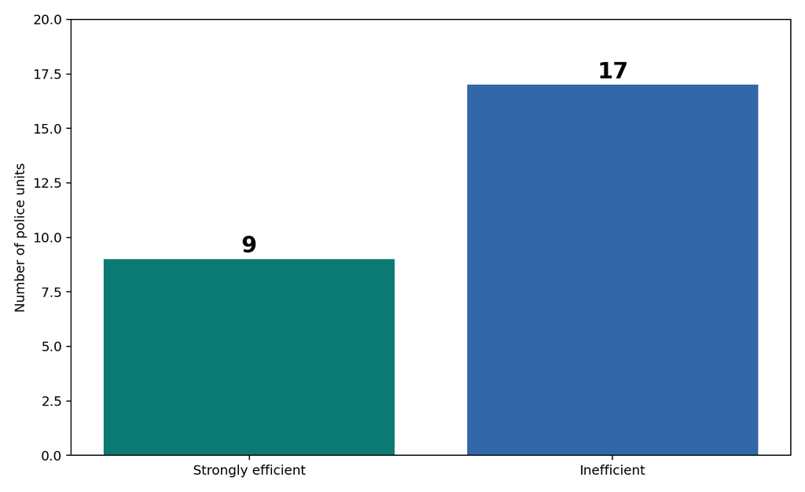

**34.6%** are strongly efficient under the specified model.

## Distribution of DEA efficiency

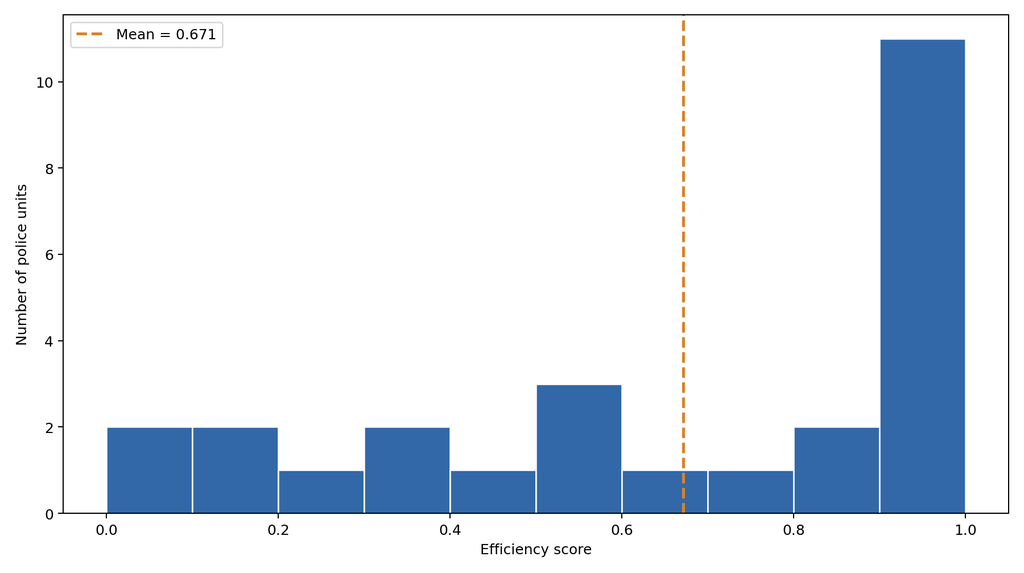

The distribution is heterogeneous, with a visible concentration at the efficient frontier and a tail of substantially underperforming units.

## Full efficiency ranking

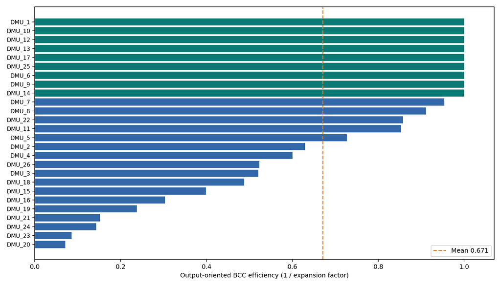

Nine units achieve score **1.000**; scores are relative to this sample and technology.

## Which units define the frontier?

**Strongly efficient units:**

DMU_1 · DMU_6 · DMU_9 · DMU_10 · DMU_12 · DMU_13 · DMU_14 · DMU_17 · DMU_25

| Illustrative frontier unit | Staff | Vehicles | Crimes | Clear-ups |
| --- | --- | --- | --- | --- |
| DMU_6 | 155 | 71 | 1,313 | 525 |
| DMU_10 | 105 | 21 | 913 | 336 |
| DMU_25 | 53 | 22 | 137 | 25 |

**Key point:** frontier units differ in size and workload, consistent with a variable-returns model.

## Largest improvement opportunities

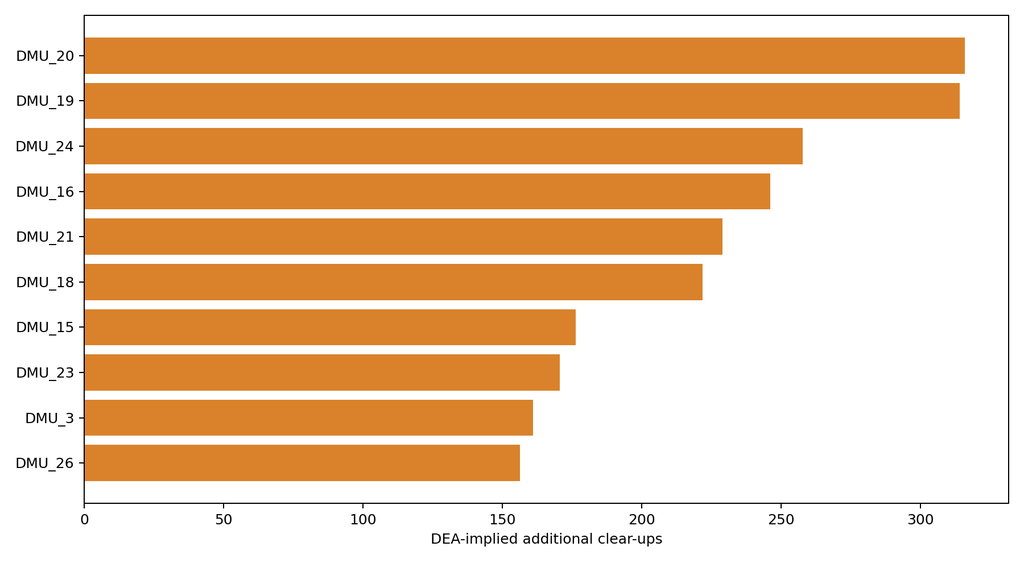

**DMU_20:** observed 24 clear-ups; DEA target approximately 339.8, or **315.8 additional**. This is a model-based benchmark comparison, not a forecast or administrative quota.

## Translating scores into operational diagnostics

| Unit | Efficiency | Observed | Target | Additional |
| --- | --- | --- | --- | --- |
| DMU_20 | 0.071 | 24 | 339.8 | 315.8 |
| DMU_19 | 0.238 | 98 | 412.0 | 314.0 |
| DMU_24 | 0.143 | 43 | 300.7 | 257.7 |
| DMU_16 | 0.303 | 107 | 353.0 | 246.0 |
| DMU_21 | 0.152 | 41 | 270.0 | 229.0 |

The estimated improvement gap is conditional on the **observed sample**, convexity, resource limits and workload restriction.

## Peer benchmarking: where to investigate

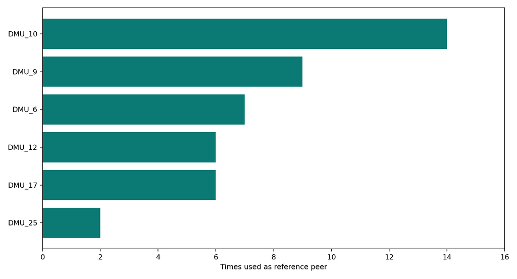

**DMU_10** is the most frequently used peer (**14 references**), followed by DMU_9 (**9**) and DMU_6 (**7**).

## Operational interpretation

- **High crime workload does not automatically imply high DEA efficiency.**
- A high clear-up rate alone is not a substitute for joint input–output benchmarking.
- Recurring peers provide candidates for studying investigative routines, deployment and management practices.
- The model identifies **relative performance gaps**, not the causal reasons behind them.

**Practical next step:** investigate what differentiates DMU_10, DMU_9, DMU_6, DMU_12 and DMU_17 from their reference units.

## Limitations and safeguards

- **Small sample:** 26 DMUs; results can be sensitive to specification and outliers.
- **Single output:** clear-ups do not capture investigation quality, crime prevention or fairness.
- **Workload assumption:** the $\ge$ crime restriction imposes one interpretation of comparability; alternative treatments warrant sensitivity checks.
- **No causal claim:** frontier targets do not establish that management alone can deliver the projected gains.
- **Data provenance:** original source agency and observation period require verification.

**Future work:** alternative workload specifications, robustness to outliers, and additional output-quality measures.

## Conclusions

**1.** Output-oriented BCC DEA with exogenous crime workload provides a transparent operational benchmarking framework.

**2.** Of 26 units, **9 are strongly efficient** and **17 have estimated improvement potential**.

**3.** Peer analysis identifies recurring best-practice references, especially **DMU_10**.

**4.** Results should guide **diagnostic investigation**, not mechanical quotas or broad claims about public safety.

## Thank you

**Questions and discussion**

Muhammad Zikriya · UFPE · GEDAI

## References

- Banker, R. D., Charnes, A., & Cooper, W. W. (1984). Some models for estimating technical and scale inefficiencies in data envelopment analysis. *Management Science*, 30(9), 1078–1092.
- Charnes, A., Cooper, W. W., & Rhodes, E. (1978). Measuring the efficiency of decision making units. *European Journal of Operational Research*, 2(6), 429–444.
- Cooper, W. W., Seiford, L. M., & Tone, K. (2007). *Data Envelopment Analysis*. Springer.